# keras_cookbook

## 0. Code Library and Links

```python
import numpy as np
import pandas as pd

import scipy
import seaborn

import matplotlib.pylab as plt
from matplotlib import cm

%matplotlib inline
```

```python
import keras
```

```python
import tensorflow.examples.tutorials.mnist as mnist
```

```python
from keras.datasets import cifar10, imdb, boston_housing
```

```python
from sklearn.datasets import make_classification
from sklearn.model_selection import train_test_split
```

```python
from keras.preprocessing import sequence
```

```python
from keras.utils import to_categorical
```

```python
from keras.models import Sequential, load_model, Model
```

```python
from keras.layers import Conv1D, MaxPooling1D, Conv2D, MaxPooling2D, GlobalAveragePooling1D
from keras.layers.embeddings import Embedding
```

```python
from keras.layers import Dense, LSTM
from keras.layers import Activation, Flatten, Dropout
from keras.layers import Input, BatchNormalization
```

```python
from keras.layers.advanced_activations import PReLU
```

## 1. Backend

```python
'''
/.keras/keras.json
{"image_data_format": "channels_last",
 "epsilon": 1e-07,
 "floatx": "float32",
 "backend": "tensorflow"}
'''
''''''
```

```
''
```

```python
# variants: "theano", "tensorflow", "cntk"
keras.backend.backend()
```

```
'tensorflow'
```

```python
keras.backend.image_dim_ordering()
```

```
'tf'
```

```python
def loss_plot(fit_history):
    plt.figure(figsize=(18, 4))

    plt.plot(fit_history.history['loss'], label = 'train')
    plt.plot(fit_history.history['val_loss'], label = 'test')

    plt.legend()
    plt.title('Loss Function');

def mae_plot(fit_history):
    plt.figure(figsize=(18, 4))

    plt.plot(fit_history.history['mean_absolute_error'], label = 'train')
    plt.plot(fit_history.history['val_mean_absolute_error'], label = 'test')

    plt.legend()
    plt.title('Mean Absolute Error');

def acc_plot(fit_history):
    plt.figure(figsize=(18, 4))

    plt.plot(fit_history.history['acc'], label = 'train')
    plt.plot(fit_history.history['val_acc'], label = 'test')

    plt.legend()
    plt.title('Accuracy');
```

## 2. Data Samples

```python
# 32x32 color images; 50,000 - the train set; 10,000 - the test set; labeled over 10 categories
(x_train1, y_train1), (x_test1, y_test1) = cifar10.load_data()
```

```python
(x_train1.shape, y_train1.shape), (x_test1.shape, y_test1.shape)
```

```
(((50000, 32, 32, 3), (50000, 1)), ((10000, 32, 32, 3), (10000, 1)))
```

```
9
```

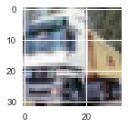

```python
print(y_train1[1][0])
plt.figure(figsize=(2,2))
plt.imshow(x_train1[1]);
```

```python
# 28x28 grayscale images; 55,000 - the train set; 10,000 - the test set; labeled over 10 categories
mnist_data = mnist.input_data.read_data_sets("MNIST_data/", one_hot=True)
```

```
Extracting MNIST_data/train-images-idx3-ubyte.gz
Extracting MNIST_data/train-labels-idx1-ubyte.gz
Extracting MNIST_data/t10k-images-idx3-ubyte.gz
Extracting MNIST_data/t10k-labels-idx1-ubyte.gz
```

```python
(x_train2, y_train2), (x_test2, y_test2) = \
(mnist_data.train.images, mnist_data.train.labels), (mnist_data.test.images, mnist_data.test.labels)
```

```python
(x_train2.shape, y_train2.shape), (x_test2.shape, y_test2.shape)
```

```
(((55000, 784), (55000, 10)), ((10000, 784), (10000, 10)))
```

```python
y_test2_class = []

for i in range(10000):
    y_test2_class.append(np.argmax(y_test2[i]))

y_test2_class = np.array(y_test2_class)
```

```
[ 0.  0.  0.  1.  0.  0.  0.  0.  0.  0.]
```

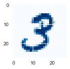

```python
print(y_train2[1])
plt.figure(figsize=(2,2))
plt.imshow(x_train2[1].reshape(28,28), cmap=cm.Blues);
```

```python
# 25,000 movies reviews from IMDB, labeled by sentiment (positive/negative)
num_words, max_length, embedding_vector_length = 10000, 1000, 32
(x_train3, y_train3), (x_test3, y_test3) = imdb.load_data(path="imdb_full.pkl", num_words=num_words,
                                                          skip_top=0, maxlen=max_length, seed=113,
                                                          start_char=1, oov_char=2, index_from=3)
```

```python
(x_train3.shape, y_train3.shape), (x_test3.shape, y_test3.shape)
```

```
(((25000,), (25000,)), ((24819,), (24819,)))
```

```python
# 13 attributes of houses at different locations, targets are the median values of the houses at a location (in k$)
(x_train4, y_train4), (x_test4, y_test4) =  boston_housing.load_data()
```

```python
(x_train4.shape, y_train4.shape), (x_test4.shape, y_test4.shape)
```

```
(((404, 13), (404,)), ((102, 13), (102,)))
```

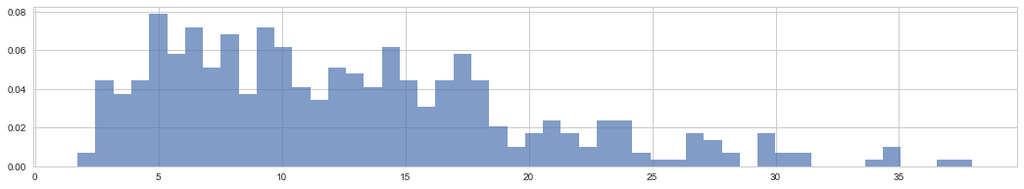

```python
plt.style.use('seaborn-whitegrid')
plt.figure(figsize=(18, 3))
plt.hist(y_train4, bins=50, normed=True, alpha=0.7);
```

```python
# classification; the artificial set, labeled over 2 categories
X5, Y5 = make_classification(n_samples=1000, n_features=2, n_redundant=0, n_informative=2)
x_train5, x_test5, y_train5, y_test5 = train_test_split(X5, Y5, test_size = 0.2, random_state = 1)
```

```python
(x_train5.shape, y_train5.shape), (x_test5.shape, y_test5.shape)
```

```
(((800, 2), (800,)), ((200, 2), (200,)))
```

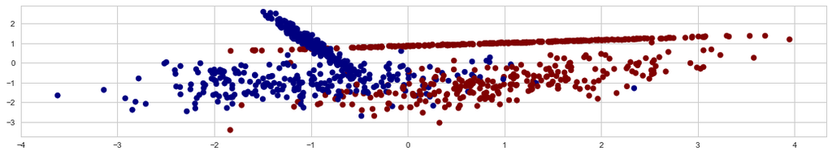

```python
plt.figure(figsize=(18, 3))
plt.scatter(X5[:, 0], X5[:, 1], marker='o', c=Y5, cmap=cm.jet);
```

## 3. Preprocessing

```python
# Sequence Padding
p_x_train3 = sequence.pad_sequences(x_train3, maxlen=max_length)
p_x_test3 = sequence.pad_sequences(x_test3, maxlen=max_length)
```

```python
# One-Hot Encoding
c_y_train1 = to_categorical(y_train1, 10)
c_y_test1 = to_categorical(y_test1, 10)

c_y_train5 = to_categorical(y_train5, 10)
c_y_test5 = to_categorical(y_test5, 10)
```

```python
[x_train5.shape, c_y_train5.shape, x_test5.shape, c_y_test5.shape]
```

```
[(800, 2), (800, 10), (200, 2), (200, 10)]
```

## 4. Models

*Optimizers:*

- 'adam', 'nadam',
- 'adagrad', 'adadelta', 'adamax',
- 'sgd', 'rmsprop',
- TFOptimizer.

*Loss functions:*

- 'mean_squared_error'('mse'), 'mean_absolute_error'('mae'),
- 'mean_absolute_percentage_error', 'mean_squared_logarithmic_error',
- 'squared_hinge', 'hinge', 'categorical_hinge',
- 'categorical_crossentropy', 'sparse_categorical_crossentropy',
- 'binary_crossentropy',
- 'kullback_leibler_divergence',
- 'poisson',
- 'cosine_proximity',
- 'logcosh'.

*Metrics:*

- mae, mse, acc,
- binary_accuracy,
- categorical_accuracy, sparse_categorical_accuracy,
- top_k_categorical_accuracy, sparse_top_k_categorical_accuracy.

##### Compilation

*For a multi-class classification problem:*

- model.compile(optimizer='adam', loss='categorical_crossentropy', metrics=['accuracy'])
- model.compile(optimizer='rmsprop', loss='categorical_crossentropy', metrics=['accuracy'])

*For a binary classification problem:*

- model.compile(optimizer='adam', loss='binary_crossentropy', metrics=['accuracy'])
- model.compile(optimizer='rmsprop', loss='binary_crossentropy', metrics=['accuracy'])

*For a mean squared error regression problem:*

- model.compile(optimizer='rmsprop', loss='mse', metrics=['mae'])
- model.compile(optimizer='sgd', loss='mse', metrics=['mae'])

##### Activation

- http://cs231n.github.io/neural-networks-1/

*Types:*

- 'elu', 'selu', 'relu', 'tanh', 'linear', 'softmax', 'softplus', 'softsign', 'sigmoid', 'hard_sigmoid'
- LeakyReLU, PReLU, ELU, ThresholdedReLU

*For a multi-class classification problem:*

- 'softmax'

*For a binary classification problem:*

- 'sigmoid'

*For a mean squared error regression problem:*

- 'linear'

##### Layers

1. *Core Layers*
   - https://keras.io/layers/core/
   - `Input` layers hold an input tensor (for example, the pixel values of the image with width 32, height 32, and 3 color channels).
   - `Dense` (fully connected) layers compute the class scores, resulting in volume of size. For example, the size [11] corresponds to class scores, such as 10 digits and 1 empty place. Each neuron in these layers are connected to all the numbers in the previous volume.
   - `Activation` applies an activation function to an output. This leaves the size of the volume unchanged.
   - `Dropout` layers consist in randomly setting a fraction rate of input units to 0 at each update during training time, which helps prevent overfitting. This leaves the size of the volume unchanged.
   - `Reshape` layers convert an output to a certain shape.
   - `Flatten` layers flatten the input and collapses it into the one-dimensional feature vector. This results in the volume such as [2, 30, 64] -> [3840].
   - etc.
2. *Convolutional Layers*
   - http://cs231n.stanford.edu/slides/2016/winter1516_lecture7.pdf
   - https://www.inf.ed.ac.uk/teaching/courses/nlu/lectures/nlu_l15_convolution-2x2.pdf
   - `Conv1D` layers (temporal convolution) convolve the filter with the signal, i.e. “is sliding over the signal vector, computing dot products”. Here the filter is an integer, the dimensionality of the output space (i.e. the number output of filters in the convolution) and the kernel size is an integer, specifying the length of the 1D convolution window.
   - `Conv2D` layers (spatial convolution over images) compute the output of neurons that are connected to local regions in the input each computing a dot product between their weights and a small region they are connected to in the input volume. This results in the volume such as [64, 64, 1] -> [64, 64, 32] when it was used 32 filters.
   - `Conv3D` layers (spatial convolution over volumes).
   - `SeparableConv2D`, `Conv2DTranspose`.
   - etc.
3. *Recurrent Layers*
   - `SimpleRNN` layers are fully-connected RNN. This leaves the size of the volume unchanged.
   - `LSTM` layers.
   - `GRU` layers.
4. *Pooling Layers*
   - http://cs231n.github.io/convolutional-networks/
   - `MaxPooling2D` layers perform a downsampling operation along the spatial dimensions (width, height). Max-pooling partitions the input image into a set of non-overlapping rectangles and, for each such subregion, outputs the maximum value. This results in the volume such as [28, 28, 32] -> [14, 14, 32].
   - `MaxPooling1D` & `MaxPooling3D` is a max pooling operation for temporal (1D) data and spatial or spatio-temporal (3D) data respectively.
5. *Advanced Activations Layers*
   - `LeakyReLU`.
     - f(x) = alpha * x for x < 0, f(x) = x for x >= 0, alpha is a small gradient.
   - `PReLU`.
     - f(x) = alpha * x for x < 0, f(x) = x for x >= 0, alpha is a learned array.
   - `ELU`.
     - f(x) = alpha * (exp(x) - 1.) for x < 0, f(x) = x for x >= 0, alpha is a small gradient.
   - `ThresholdedReLU`.
     - f(x) = x for x > theta, f(x) = 0 otherwise.

etc.

```python
# the basic example (binary classification)
basic_model = Sequential([Dense(16, input_dim=2), Activation('relu'), Dense(1), Activation('sigmoid')])
basic_model.compile(optimizer='adam', loss='binary_crossentropy', metrics=['accuracy'])
```

```python
# train the model
basic_model.fit(x_train5, y_train5, epochs=100, batch_size=8, verbose=0)
# predict classes
y_train5_predictions = basic_model.predict_classes(x_train5)
```

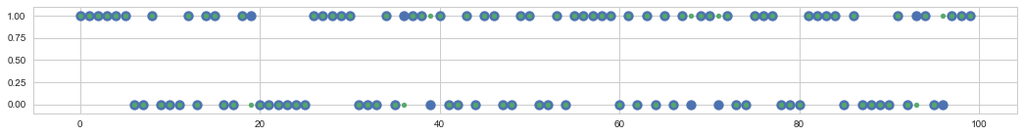

```python
plt.figure(figsize=(18,2))
plt.scatter(range(100), y_train5[:100], s=100)
plt.scatter(range(100), y_train5_predictions[:100], s=25)
```

```python
# model performance
basic_score = basic_model.evaluate(x_test5, y_test5, batch_size=200)
basic_score
```

```
[0.24358490109443665, 0.91500002145767212]
```

```python
basic_model.input
```

```
<tf.Tensor 'dense_1_input:0' shape=(?, 2) dtype=float32>
```

```python
# model parameters
basic_model.output_shape
```

```
(None, 1)
```

```python
basic_model.summary()
```

```
_________________________________________________________________
Layer (type)                 Output Shape              Param #
=================================================================
dense_1 (Dense)              (None, 16)                48
_________________________________________________________________
activation_1 (Activation)    (None, 16)                0
_________________________________________________________________
dense_2 (Dense)              (None, 1)                 17
_________________________________________________________________
activation_2 (Activation)    (None, 1)                 0
=================================================================
Total params: 65
Trainable params: 65
Non-trainable params: 0
_________________________________________________________________
```

```python
basic_model.get_config()
```

```
[{'class_name': 'Dense',
  'config': {'activation': 'linear',
   'activity_regularizer': None,
   'batch_input_shape': (None, 2),
   'bias_constraint': None,
   'bias_initializer': {'class_name': 'Zeros', 'config': {}},
   'bias_regularizer': None,
   'dtype': 'float32',
   'kernel_constraint': None,
   'kernel_initializer': {'class_name': 'VarianceScaling',
    'config': {'distribution': 'uniform',
     'mode': 'fan_avg',
     'scale': 1.0,
     'seed': None}},
   'kernel_regularizer': None,
   'name': 'dense_1',
   'trainable': True,
   'units': 16,
   'use_bias': True}},
 {'class_name': 'Activation',
  'config': {'activation': 'relu', 'name': 'activation_1', 'trainable': True}},
 {'class_name': 'Dense',
  'config': {'activation': 'linear',
   'activity_regularizer': None,
   'bias_constraint': None,
   'bias_initializer': {'class_name': 'Zeros', 'config': {}},
   'bias_regularizer': None,
   'kernel_constraint': None,
   'kernel_initializer': {'class_name': 'VarianceScaling',
    'config': {'distribution': 'uniform',
     'mode': 'fan_avg',
     'scale': 1.0,
     'seed': None}},
   'kernel_regularizer': None,
   'name': 'dense_2',
   'trainable': True,
   'units': 1,
   'use_bias': True}},
 {'class_name': 'Activation',
  'config': {'activation': 'sigmoid',
   'name': 'activation_2',
   'trainable': True}}]
```

```python
basic_model.get_weights()
```

```
[array([[  1.14994794e-01,   7.40971804e-01,   8.99386585e-01,
          -4.07450944e-01,   2.94178903e-01,  -6.02532387e-01,
          -9.98718083e-01,   2.71358520e-01,   1.05556063e-01,
          -1.16264641e+00,   7.75020421e-02,   1.34263968e+00,
          -1.03764474e+00,   3.16809505e-01,   2.81166047e-01,
           2.78677106e-01],
        [  1.33933183e-02,   2.77992576e-01,  -2.03157246e-01,
          -7.13215619e-02,  -8.58754098e-01,  -1.85627684e-01,
          -1.45962209e-01,  -7.88673759e-01,  -6.95272863e-01,
          -1.34547785e-01,  -2.60396600e-02,   8.37370753e-01,
          -1.03351113e-03,  -7.28389382e-01,  -8.61480474e-01,
          -5.82629621e-01]], dtype=float32),
 array([-0.31003574,  0.46265444,  0.24866888,  0.08661296, -0.55431366,
        -0.41512805,  0.12150027, -0.50935674,  0.58840513,  0.17249312,
        -0.23443536,  0.43791035,  0.13509141, -0.45524761, -0.55908656,
        -0.34777483], dtype=float32),
 array([[-0.07727471],
        [ 1.13152349],
        [-0.87979442],
        [-0.39165819],
        [ 1.3199923 ],
        [ 1.10043001],
        [-0.85114253],
        [ 0.78520453],
        [-0.77333343],
        [-0.53742957],
        [-0.33091313],
        [ 1.48460662],
        [-0.75646085],
        [ 0.39228868],
        [ 1.0166688 ],
        [ 0.93689066]], dtype=float32),
 array([ 0.05159498], dtype=float32)]
```

```python
# optimization

opt = keras.optimizers.rmsprop(lr=0.001, decay=1e-5)
opt2 = keras.optimizers.SGD(lr=0.001, decay=1e-5, momentum=0.9, nesterov=True)

basic_model2 = Sequential([Dense(16, input_dim=2), Activation('relu'), Dense(1), Activation('sigmoid')])
basic_model2.compile(optimizer=opt2, loss='binary_crossentropy', metrics=['accuracy'])
```

```python
basic_model2.fit(x_train5, y_train5, batch_size=8, epochs=100, verbose=0)

basic_score2 = basic_model2.evaluate(x_test5, y_test5, batch_size=200)
basic_score2
```

```
[0.26739662885665894, 0.90499997138977051]
```

```python
# advanced activation

# encoder
inp = Input(shape=(2,))
act = PReLU(alpha_initializer='zeros')
lay = Dense(16, kernel_initializer='uniform', name='encoder')(inp)
lay = act(lay)

# decoder
out = Dense(1, kernel_initializer='uniform', activation='sigmoid', name='decoder')(lay)

# model
basic_model3 = Model(inputs=inp, outputs=out, name='cae')
basic_model3.compile(optimizer='adam', loss='binary_crossentropy', metrics=['accuracy'])
```

```python
basic_model3.fit(x_train5, y_train5, epochs=100, batch_size=8, verbose=0)
basic_model3.evaluate(x_test5, y_test5, batch_size=200)
```

```
[0.25685057044029236, 0.9100000262260437]
```

```python
# save/reload models
basic_model.save('basic_model_file.h5')
my_basic_model = load_model('basic_model_file.h5')
```

## 5. Neural Networks

### 5.1 Multi-layer Perceptron

```python
# MLP: Binary Classification
def mlp_bc_model():
    model = Sequential()

    model.add(Dense(8, input_dim=2, kernel_initializer='uniform', activation='relu'))
    model.add(Dense(16, kernel_initializer='uniform', activation='relu'))

    model.add(Dropout(0.25))

    model.add(Dense(1, kernel_initializer='uniform', activation='sigmoid'))

    model.compile(optimizer='adam', loss='binary_crossentropy', metrics=['accuracy'])
    return model
```

```python
mlp_bc_model = mlp_bc_model()
mlp_bc_model.fit(x_train5, y_train5, epochs=100, batch_size=8, verbose=0)
y_train5_mlp_predictions = mlp_bc_model.predict_classes(x_train5)
y_test5_mlp_predictions = mlp_bc_model.predict_classes(x_test5)
```

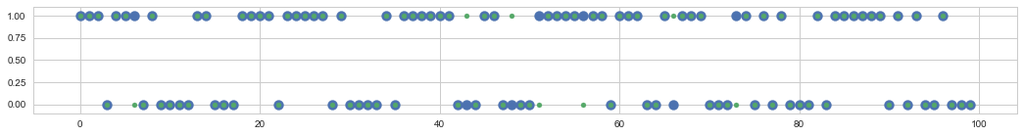

```python
plt.figure(figsize=(18,2))
plt.scatter(range(100), y_test5[:100], s=100)
plt.scatter(range(100), y_test5_mlp_predictions[:100], s=25);
```

```python
mlp_bc_test_score = mlp_bc_model.evaluate(x_test5, y_test5, batch_size=200)
mlp_bc_test_score
```

```
[0.25528141856193542, 0.91500002145767212]
```

```python
# MLP: Multi-Class Classification
def mlp_mc_model():
    model = Sequential()

    model.add(Dense(196, activation='relu', input_shape=(784,)))
    model.add(Dropout(0.2))

    model.add(Dense(784, activation='relu'))
    model.add(Dropout(0.2))

    model.add(Dense(10, activation='softmax'))

    model.compile(optimizer='adam', loss='categorical_crossentropy', metrics=['accuracy'])
    return model
```

```python
mlp_mc_model = mlp_mc_model()
mlp_mc_model.fit(x_train2, y_train2, epochs=10, batch_size=8, verbose=0)
y_train2_mlp_predictions = mlp_mc_model.predict_classes(x_train2)
y_test2_mlp_predictions = mlp_mc_model.predict_classes(x_test2)
```

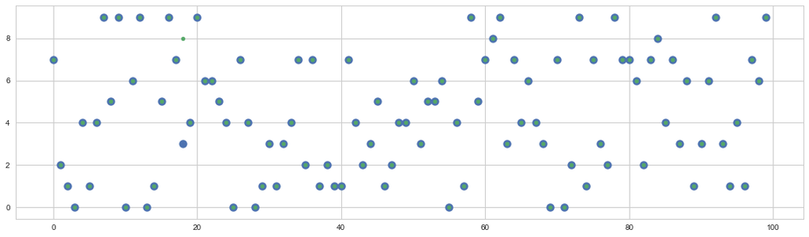

```python
plt.figure(figsize=(18,5))
plt.scatter(range(100), y_test2_class[:100], s=100)
plt.scatter(range(100), y_test2_mlp_predictions[:100], s=25);
```

```python
mlp_mc_test_score = mlp_mc_model.evaluate(x_test2, y_test2)
mlp_mc_test_score
```

```
[0.10468304518835775, 0.97789999999999999]
```

```python
# MLP: Regression
def mlp_reg_model():
    model = Sequential()

    model.add(Dense(13, activation='relu', input_dim=13))
    model.add(Dense(104, activation='relu'))
    model.add(Dense(416, activation='relu'))

    model.add(Dense(1))

    model.compile(optimizer='rmsprop', loss='mse', metrics=['mae'])

    return model
```

```python
mlp_reg_model = mlp_reg_model()
mlp_reg_history = mlp_reg_model.fit(x_train4, y_train4, epochs=100, batch_size=16, verbose=0,
                                    validation_data=(x_test4, y_test4))
y_train4_mlp_predictions = mlp_reg_model.predict(x_train4)
y_test4_mlp_predictions = mlp_reg_model.predict(x_test4)
```

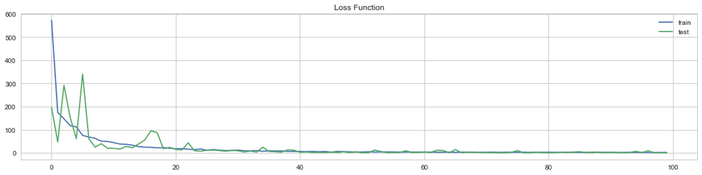

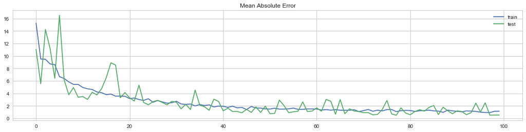

```python
loss_plot(mlp_reg_history)
mae_plot(mlp_reg_history)
```

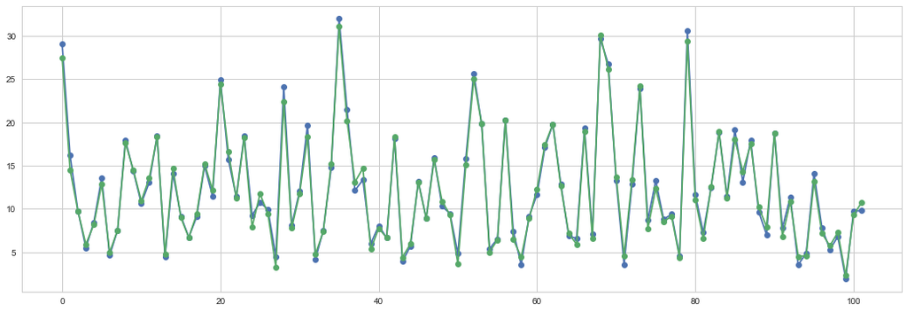

```python
plt.figure(figsize=(18,6))
plt.plot(range(len(y_test4)), y_test4, '-o', label = 'real data')
plt.plot(range(len(y_test4)), y_test4_mlp_predictions, '-o', label = 'predictions');
```

```python
mlp_reg_test_score = mlp_reg_model.evaluate(x_test4, y_test4, batch_size=102)
mlp_reg_test_score
```

```
[0.45933929085731506, 0.54101449251174927]
```

### 5.2 Convolutional Neural Network (CNN)

```python
# CNN: Binary Classification
def cnn_bc_model():
    model = Sequential()

    model.add(Conv1D(filters=16, kernel_size=5, padding='same',
                     activation='relu', input_shape=(2,1)))
    model.add(Conv1D(filters=16, kernel_size=5, padding='same', activation='relu'))

    model.add(MaxPooling1D(pool_size=2))
    model.add(Dropout(0.25))

    model.add(Dense(1, kernel_initializer='uniform', activation='sigmoid'))

    model.compile(optimizer='adam', loss='binary_crossentropy', metrics=['accuracy'])

    return model
```

```python
cnn_bc_model = cnn_bc_model()
cnn_bc_model.fit(x_train5.reshape(800, 2, 1), y_train5.reshape(800, 1, 1), epochs=100, batch_size=8, verbose=0,
                 validation_data=(x_test5.reshape(200, 2, 1), y_test5.reshape(200, 1, 1)))
y_train5_cnn_predictions = cnn_bc_model.predict_classes(x_train5.reshape(800, 2, 1))
y_test5_cnn_predictions = cnn_bc_model.predict_classes(x_test5.reshape(200, 2, 1))
```

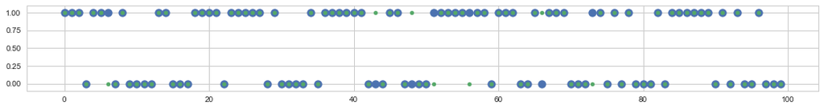

```python
plt.figure(figsize=(18,2))
plt.scatter(range(100), y_test5[:100], s=100)
plt.scatter(range(100), y_test5_cnn_predictions[:100], s=25);
```

```python
cnn_bc_test_score = cnn_bc_model.evaluate(x_test5.reshape(200, 2, 1), y_test5.reshape(200, 1, 1), batch_size=200)
cnn_bc_test_score
```

```
[0.18861152231693268, 0.92500001192092896]
```

```python
# CNN: LSTM For Sequence Classification
def cnn_lstm_model():
    model = Sequential()

    model.add(Embedding(num_words, embedding_vector_length, input_length=max_length))

    model.add(Conv1D(filters=32, kernel_size=3, padding='same', activation='relu'))
    model.add(MaxPooling1D(pool_size=2))

    model.add(LSTM(32))

    model.add(Dense(1, activation='sigmoid'))

    model.compile(loss='binary_crossentropy', optimizer='nadam', metrics=['accuracy'])

    return model
```

```python
cnn_lstm_model = cnn_lstm_model()
cnn_lstm_history = cnn_lstm_model.fit(p_x_train3, y_train3, epochs=3, batch_size=128,
                                      validation_data=(p_x_test3, y_test3))
```

```
Train on 25000 samples, validate on 24819 samples
```

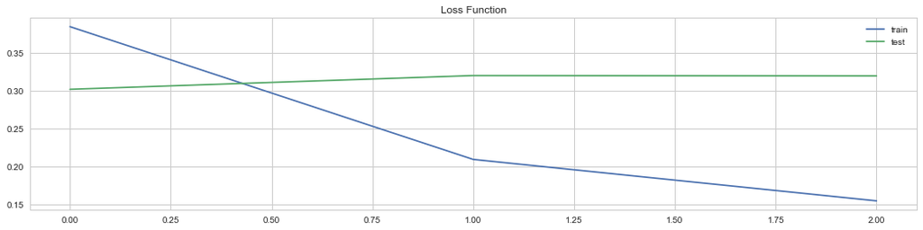

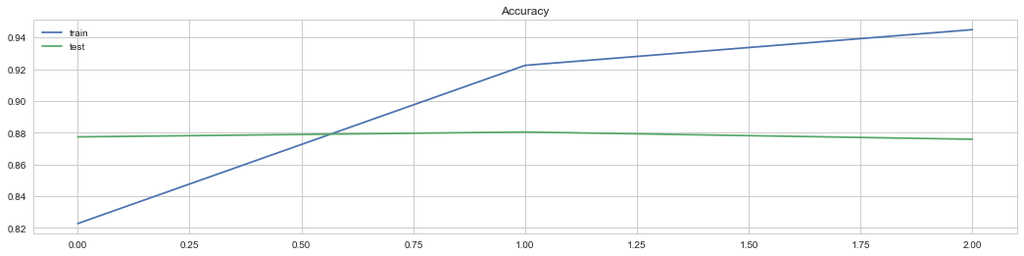

```python
loss_plot(cnn_lstm_history)
acc_plot(cnn_lstm_history)
```

```python
cnn_lstm_scores = cnn_lstm_model.evaluate(p_x_test3, y_test3, verbose=2)
print("Accuracy: %.2f%%" % (cnn_lstm_scores[1]*100))
```

```
Accuracy: 87.09%
```

```python
# VGG-like CNN: Multi-Class Classification
def cnn_vgg_model():
    model = Sequential()

    model.add(Conv2D(32, (3, 3), padding='same', input_shape=x_train1.shape[1:]))
    model.add(Activation('relu'))
    model.add(Conv2D(32, (3, 3)))
    model.add(Activation('relu'))

    model.add(MaxPooling2D(pool_size=(2, 2)))
    model.add(Dropout(0.2))

    model.add(Conv2D(64, (3, 3), padding='same'))
    model.add(Activation('relu'))
    model.add(Conv2D(64, (3, 3)))
    model.add(Activation('relu'))

    model.add(MaxPooling2D(pool_size=(2, 2)))
    model.add(Dropout(0.2))

    model.add(Flatten())

    model.add(Dense(512))
    model.add(Activation('relu'))
    model.add(Dropout(0.4))

    model.add(Dense(10))
    model.add(Activation('softmax'))

    opt = keras.optimizers.rmsprop(lr=0.0001, decay=1e-6)

    model.compile(loss='categorical_crossentropy', optimizer=opt, metrics=['accuracy'])

    return model
```

```python
cnn_vgg_model = cnn_vgg_model()
cnn_vgg_history = cnn_vgg_model.fit(x_train1, c_y_train1, epochs=50, batch_size=64, verbose=2,
                                    validation_data=(x_test1, c_y_test1))
y_train1_cnn_predictions = cnn_vgg_model.predict_classes(x_train1)
y_test1_cnn_predictions = cnn_vgg_model.predict_classes(x_test1)
```

```
Train on 50000 samples, validate on 10000 samples
382s - loss: 2.9090 - acc: 0.2978 - val_loss: 1.4964 - val_acc: 0.4670
413s - loss: 1.5024 - acc: 0.4611 - val_loss: 1.3398 - val_acc: 0.5187
460s - loss: 1.3309 - acc: 0.5260 - val_loss: 1.3110 - val_acc: 0.5477
394s - loss: 1.2210 - acc: 0.5659 - val_loss: 1.1132 - val_acc: 0.6123
358s - loss: 1.1355 - acc: 0.5996 - val_loss: 1.1051 - val_acc: 0.6057
360s - loss: 1.0700 - acc: 0.6248 - val_loss: 1.0343 - val_acc: 0.6359
396s - loss: 1.0189 - acc: 0.6450 - val_loss: 1.0257 - val_acc: 0.6436
353s - loss: 0.9774 - acc: 0.6606 - val_loss: 1.0352 - val_acc: 0.6413
352s - loss: 0.9364 - acc: 0.6756 - val_loss: 0.9448 - val_acc: 0.6716
351s - loss: 0.9002 - acc: 0.6874 - val_loss: 1.0244 - val_acc: 0.6525
350s - loss: 0.8789 - acc: 0.6959 - val_loss: 0.8588 - val_acc: 0.7060
353s - loss: 0.8500 - acc: 0.7076 - val_loss: 0.9425 - val_acc: 0.6857
352s - loss: 0.8301 - acc: 0.7151 - val_loss: 0.9928 - val_acc: 0.6655
351s - loss: 0.8072 - acc: 0.7249 - val_loss: 0.8457 - val_acc: 0.7120
358s - loss: 0.7917 - acc: 0.7293 - val_loss: 0.8452 - val_acc: 0.7136
356s - loss: 0.7817 - acc: 0.7311 - val_loss: 0.8165 - val_acc: 0.7265
352s - loss: 0.7651 - acc: 0.7390 - val_loss: 0.8144 - val_acc: 0.7306
352s - loss: 0.7472 - acc: 0.7429 - val_loss: 0.7710 - val_acc: 0.7403
356s - loss: 0.7405 - acc: 0.7477 - val_loss: 0.8607 - val_acc: 0.7111
352s - loss: 0.7296 - acc: 0.7510 - val_loss: 0.7926 - val_acc: 0.7437
351s - loss: 0.7222 - acc: 0.7555 - val_loss: 0.8246 - val_acc: 0.7204
351s - loss: 0.7093 - acc: 0.7576 - val_loss: 0.7428 - val_acc: 0.7514
352s - loss: 0.7059 - acc: 0.7608 - val_loss: 0.7780 - val_acc: 0.7420
351s - loss: 0.6997 - acc: 0.7632 - val_loss: 0.7824 - val_acc: 0.7483
352s - loss: 0.6969 - acc: 0.7654 - val_loss: 0.8097 - val_acc: 0.7340
351s - loss: 0.6858 - acc: 0.7664 - val_loss: 0.7557 - val_acc: 0.7577
352s - loss: 0.6805 - acc: 0.7697 - val_loss: 0.7928 - val_acc: 0.7352
352s - loss: 0.6776 - acc: 0.7728 - val_loss: 0.8040 - val_acc: 0.7433
351s - loss: 0.6769 - acc: 0.7745 - val_loss: 0.8541 - val_acc: 0.7508
351s - loss: 0.6738 - acc: 0.7751 - val_loss: 0.8750 - val_acc: 0.7443
352s - loss: 0.6740 - acc: 0.7724 - val_loss: 0.7332 - val_acc: 0.7568
351s - loss: 0.6650 - acc: 0.7763 - val_loss: 0.7482 - val_acc: 0.7593
352s - loss: 0.6628 - acc: 0.7759 - val_loss: 0.7671 - val_acc: 0.7513
351s - loss: 0.6548 - acc: 0.7791 - val_loss: 0.7409 - val_acc: 0.7645
351s - loss: 0.6567 - acc: 0.7801 - val_loss: 0.7763 - val_acc: 0.7568
352s - loss: 0.6587 - acc: 0.7801 - val_loss: 0.8046 - val_acc: 0.7524
351s - loss: 0.6541 - acc: 0.7814 - val_loss: 0.7423 - val_acc: 0.7639
353s - loss: 0.6523 - acc: 0.7837 - val_loss: 0.8571 - val_acc: 0.7561
350s - loss: 0.6473 - acc: 0.7834 - val_loss: 0.7492 - val_acc: 0.7554
350s - loss: 0.6494 - acc: 0.7835 - val_loss: 0.7494 - val_acc: 0.7578
349s - loss: 0.6454 - acc: 0.7850 - val_loss: 0.7266 - val_acc: 0.7647
351s - loss: 0.6452 - acc: 0.7847 - val_loss: 0.7982 - val_acc: 0.7688
351s - loss: 0.6434 - acc: 0.7876 - val_loss: 0.7882 - val_acc: 0.7553
350s - loss: 0.6410 - acc: 0.7874 - val_loss: 0.7159 - val_acc: 0.7727
351s - loss: 0.6351 - acc: 0.7903 - val_loss: 0.7773 - val_acc: 0.7580
352s - loss: 0.6384 - acc: 0.7878 - val_loss: 0.7563 - val_acc: 0.7666
353s - loss: 0.6324 - acc: 0.7902 - val_loss: 0.8293 - val_acc: 0.7508
355s - loss: 0.6334 - acc: 0.7895 - val_loss: 0.7760 - val_acc: 0.7587
351s - loss: 0.6328 - acc: 0.7913 - val_loss: 0.7749 - val_acc: 0.7574
351s - loss: 0.6409 - acc: 0.7881 - val_loss: 0.7431 - val_acc: 0.7706
```

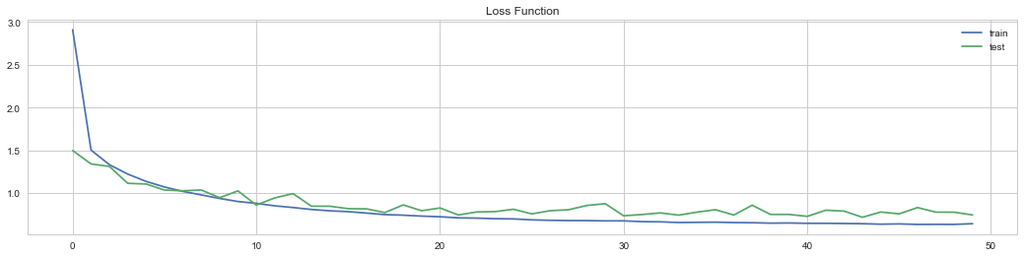

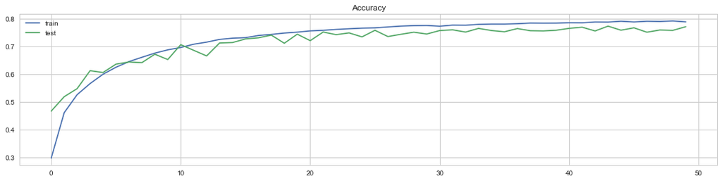

```python
loss_plot(cnn_vgg_history)
acc_plot(cnn_vgg_history)
```

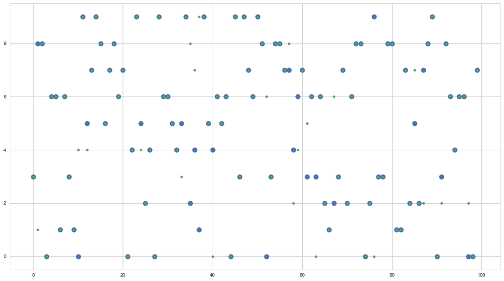

```python
plt.figure(figsize=(18,10))
plt.scatter(range(100), y_test1[:100], s=100)
plt.scatter(range(100), y_test1_cnn_predictions[:100], s=25);
```

```python
cnn_vgg_test_score = cnn_vgg_model.evaluate(x_test1, c_y_test1)
cnn_vgg_test_score
```

```
[0.74313305077552794, 0.77059999999999995]
```

```python
x_train4.shape, x_test4.shape
```

```
((404, 13), (102, 13))
```

```python
# CNN: Regression
def cnn_reg_model():
    model = Sequential()

#    model.add(BatchNormalization(input_shape=(13,1)))

    model.add(Conv1D(13, 5, padding='valid', activation='relu', input_shape=(13,1)))
    model.add(MaxPooling1D(pool_size=2))
    model.add(Dropout(0.2))

    model.add(Conv1D(104, 3, padding='valid', activation='relu'))
    model.add(MaxPooling1D(pool_size=2))
    model.add(Dropout(0.2))

    model.add(Flatten())

    model.add(Dense(832, kernel_initializer='normal', activation='relu'))
    model.add(Dropout(0.4))

    model.add(Dense(1, kernel_initializer='normal'))

#    opt = keras.optimizers.rmsprop(decay=1e-6)

    model.compile(loss='mse', optimizer='rmsprop', metrics=['mae'])
    return model
```

```python
cnn_reg_model = cnn_reg_model()
cnn_reg_history = cnn_reg_model.fit(x_train4.reshape(404, 13, 1), y_train4, epochs=1600, batch_size=13, verbose=0,
                                    validation_data=(x_test4.reshape(102, 13, 1), y_test4))
y_train4_cnn_predictions = cnn_reg_model.predict(x_train4.reshape(404, 13, 1))
y_test4_cnn_predictions = cnn_reg_model.predict(x_test4.reshape(102, 13, 1))
```

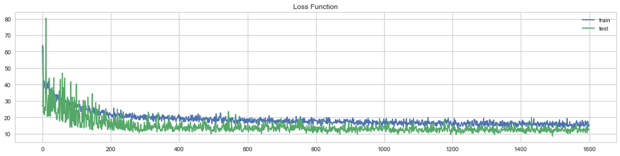

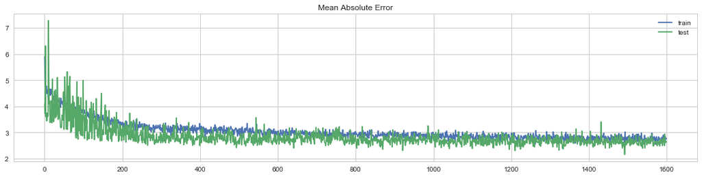

```python
loss_plot(cnn_reg_history)
mae_plot(cnn_reg_history)
```

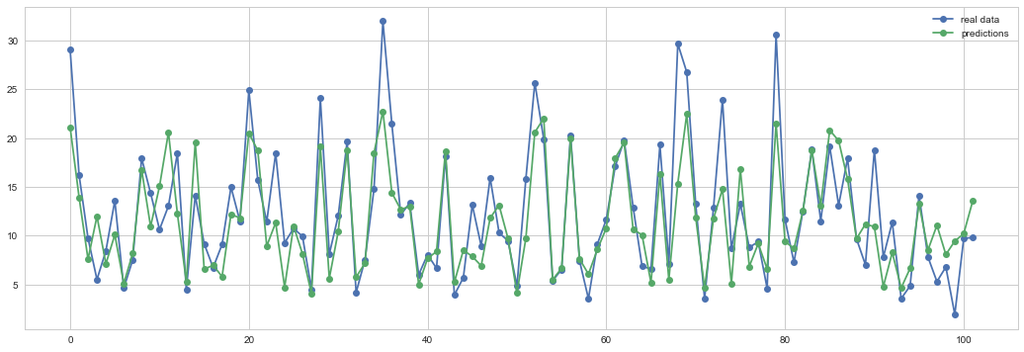

```python
# epochs=400
plt.figure(figsize=(18,6))
plt.plot(range(len(y_test4)), y_test4, '-o', label = 'real data')
plt.plot(range(len(y_test4)), y_test4_cnn_predictions, '-o', label = 'predictions')
plt.legend();
```

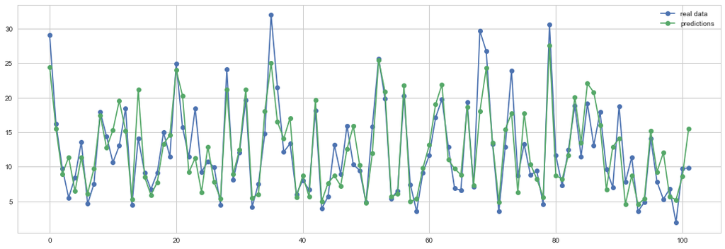

```python
# epochs=800
plt.figure(figsize=(18,6))
plt.plot(range(len(y_test4)), y_test4, '-o', label = 'real data')
plt.plot(range(len(y_test4)), y_test4_cnn_predictions, '-o', label = 'predictions')
plt.legend();
```

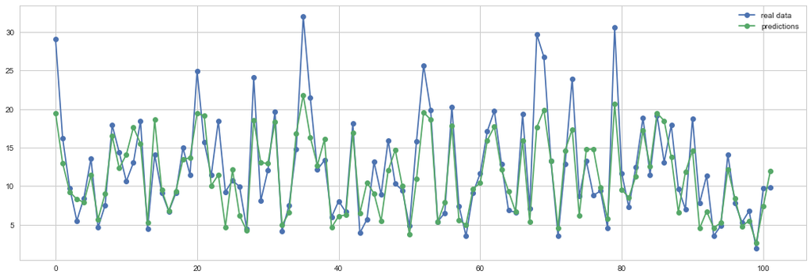

```python
# epochs=1600
plt.figure(figsize=(18,6))
plt.plot(range(len(y_test4)), y_test4, '-o', label = 'real data')
plt.plot(range(len(y_test4)), y_test4_cnn_predictions, '-o', label = 'predictions')
plt.legend();
```

### 5.3 Recurrent Neural Network (RNN)

```python
# RNN: Binary Classification
def rnn_bc_model():
    model = Sequential()

    model.add(LSTM(32, dropout=0.2, recurrent_dropout=0.2, input_shape=(1, 2)))
    model.add(Dense(1, activation='sigmoid'))

    model.compile(loss='binary_crossentropy', optimizer='adam', metrics=['accuracy'])

    return model
```

```python
rnn_bc_model = rnn_bc_model()
rnn_bc_history = rnn_bc_model.fit(x_train5.reshape(x_train5.shape[0], 1, x_train5.shape[1]),
                                  y_train5.reshape(y_train5.shape[0], 1),
                                  epochs=20, batch_size=32, verbose=2,
                                  validation_data=(x_test5.reshape(x_test5.shape[0], 1, x_test5.shape[1]),
                                                   y_test5.reshape(y_test5.shape[0], 1)))
y_train5_rnn_predictions = rnn_bc_model.predict_classes(x_train5.reshape(x_train5.shape[0], 1, x_train5.shape[1]))
y_test5_rnn_predictions = rnn_bc_model.predict_classes(x_test5.reshape(x_test5.shape[0], 1, x_test5.shape[1]))
```

```
Train on 800 samples, validate on 200 samples
11s - loss: 0.6834 - acc: 0.6088 - val_loss: 0.6673 - val_acc: 0.8150
0s - loss: 0.6551 - acc: 0.8000 - val_loss: 0.6397 - val_acc: 0.8700
0s - loss: 0.6261 - acc: 0.8163 - val_loss: 0.6103 - val_acc: 0.8700
0s - loss: 0.5958 - acc: 0.8212 - val_loss: 0.5792 - val_acc: 0.8500
0s - loss: 0.5737 - acc: 0.8025 - val_loss: 0.5488 - val_acc: 0.8400
0s - loss: 0.5333 - acc: 0.8362 - val_loss: 0.5148 - val_acc: 0.8550
0s - loss: 0.5098 - acc: 0.8325 - val_loss: 0.4837 - val_acc: 0.8500
0s - loss: 0.4862 - acc: 0.8625 - val_loss: 0.4541 - val_acc: 0.8550
0s - loss: 0.4539 - acc: 0.8513 - val_loss: 0.4272 - val_acc: 0.8550
0s - loss: 0.4368 - acc: 0.8612 - val_loss: 0.4042 - val_acc: 0.8550
0s - loss: 0.4074 - acc: 0.8575 - val_loss: 0.3842 - val_acc: 0.8600
0s - loss: 0.4017 - acc: 0.8638 - val_loss: 0.3677 - val_acc: 0.8700
0s - loss: 0.3860 - acc: 0.8663 - val_loss: 0.3541 - val_acc: 0.8700
0s - loss: 0.3899 - acc: 0.8575 - val_loss: 0.3424 - val_acc: 0.8800
0s - loss: 0.3751 - acc: 0.8463 - val_loss: 0.3333 - val_acc: 0.8750
0s - loss: 0.3622 - acc: 0.8750 - val_loss: 0.3267 - val_acc: 0.8750
0s - loss: 0.3567 - acc: 0.8525 - val_loss: 0.3215 - val_acc: 0.8800
0s - loss: 0.3517 - acc: 0.8588 - val_loss: 0.3174 - val_acc: 0.8800
0s - loss: 0.3465 - acc: 0.8562 - val_loss: 0.3144 - val_acc: 0.8800
0s - loss: 0.3406 - acc: 0.8750 - val_loss: 0.3109 - val_acc: 0.8750
```

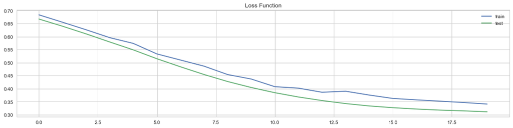

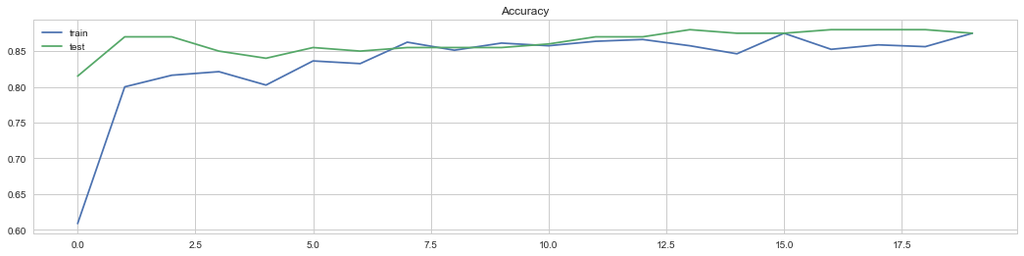

```python
loss_plot(rnn_bc_history)
acc_plot(rnn_bc_history)
```

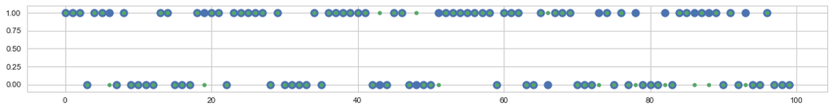

```python
plt.figure(figsize=(18,2))
plt.scatter(range(100), y_test5[:100], s=100)
plt.scatter(range(100), y_test5_rnn_predictions[:100], s=25);
```

```python
# RNN: Multi-Class Classification
def rnn_mc_model():
    model = Sequential()

    model.add(LSTM(112, return_sequences=True, input_shape=(1,784)))

    model.add(LSTM(112, return_sequences=True))
    model.add(LSTM(112))

    model.add(Dense(10, activation='softmax'))

    model.compile(loss='categorical_crossentropy', optimizer='nadam', metrics=['accuracy'])
    return model
```

```python
rnn_mc_model = rnn_mc_model()
rnn_mc_history = rnn_mc_model.fit(x_train2.reshape(x_train2.shape[0], 1, x_train2.shape[1]), y_train2,
                                  epochs=3, batch_size=112, verbose=2,
                                  validation_data=(x_test2.reshape(x_test2.shape[0], 1, x_test2.shape[1]), y_test2))
y_train2_rnn_predictions = rnn_mc_model.predict_classes(x_train2.reshape(x_train2.shape[0], 1, x_train2.shape[1]))
y_test2_rnn_predictions = rnn_mc_model.predict_classes(x_test2.reshape(x_test2.shape[0], 1, x_test2.shape[1]))
```

```
Train on 55000 samples, validate on 10000 samples
58s - loss: 0.2995 - acc: 0.9116 - val_loss: 0.3894 - val_acc: 0.9021
32s - loss: 0.1009 - acc: 0.9701 - val_loss: 0.1062 - val_acc: 0.9673
31s - loss: 0.0675 - acc: 0.9792 - val_loss: 0.0952 - val_acc: 0.9709
```

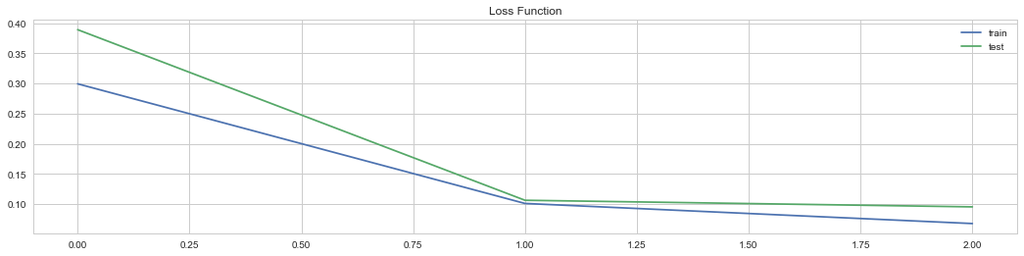

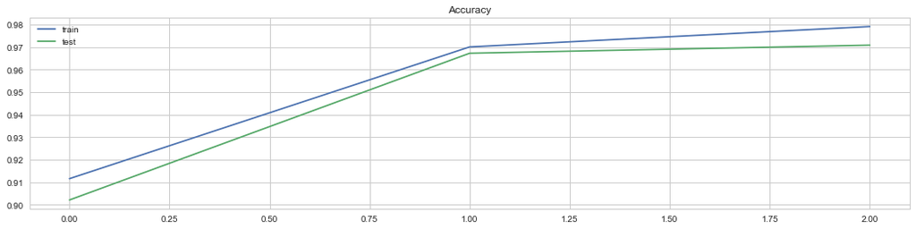

```python
loss_plot(rnn_mc_history)
acc_plot(rnn_mc_history)
```

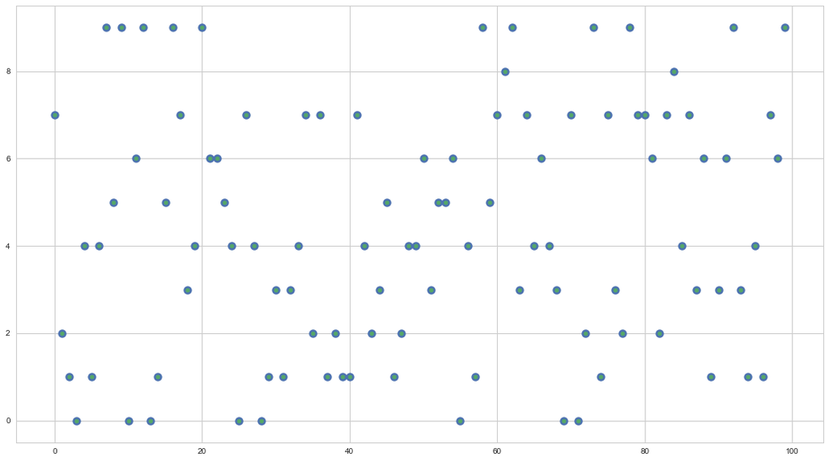

```python
plt.figure(figsize=(18,10))
plt.scatter(range(100), y_test2_class[:100], s=100)
plt.scatter(range(100), y_test2_rnn_predictions[:100], s=25);
```

```python
# RNN: Regression
def rnn_reg_model():
    model = Sequential()

    model.add(LSTM(52, return_sequences=True, input_shape=(1, 13)))
    model.add(LSTM(208, return_sequences=False))

    model.add(Dense(1))

    model.compile(optimizer='rmsprop', loss='mse', metrics=['mae'])

    return model
```

```python
rnn_reg_model = rnn_reg_model()

rnn_reg_history = rnn_reg_model.fit(x_train4.reshape(x_train4.shape[0], 1, x_train4.shape[1]), y_train4,
                                    validation_data=(x_test4.reshape(x_test4.shape[0], 1, x_test4.shape[1]),y_test4),
                                    epochs=800, verbose=0)
```

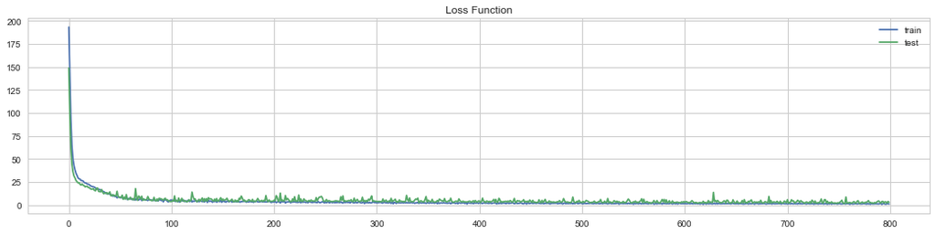

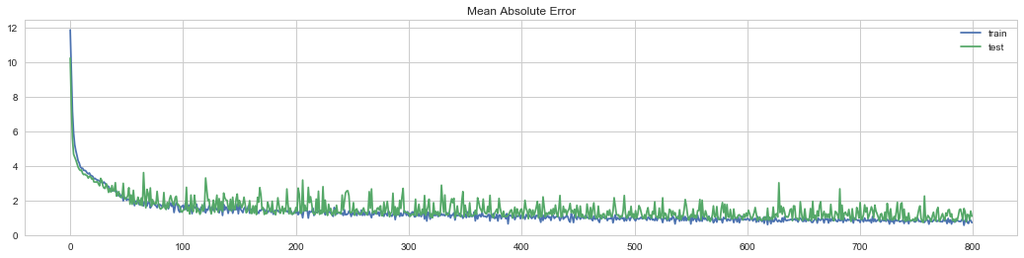

```python
loss_plot(rnn_reg_history)
mae_plot(rnn_reg_history)
```

```python
y_train4_rnn_predictions = rnn_reg_model.predict(x_train4.reshape(x_train4.shape[0], 1, x_train4.shape[1]))
y_test4_rnn_predictions = rnn_reg_model.predict(x_test4.reshape(102, 1, 13))
```

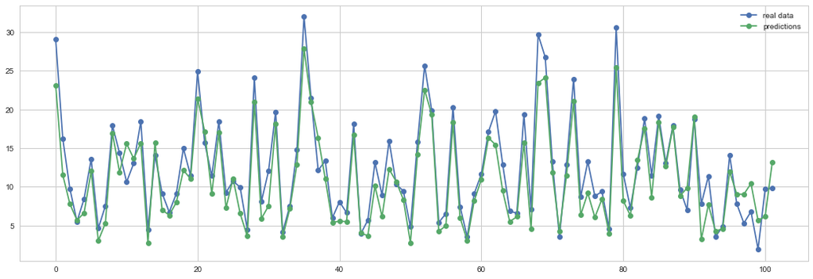

```python
# epochs=50
plt.figure(figsize=(18,6))
plt.plot(range(len(y_test4)), y_test4, '-o', label = 'real data')
plt.plot(range(len(y_test4)), y_test4_rnn_predictions, '-o', label = 'predictions')
plt.legend();
```

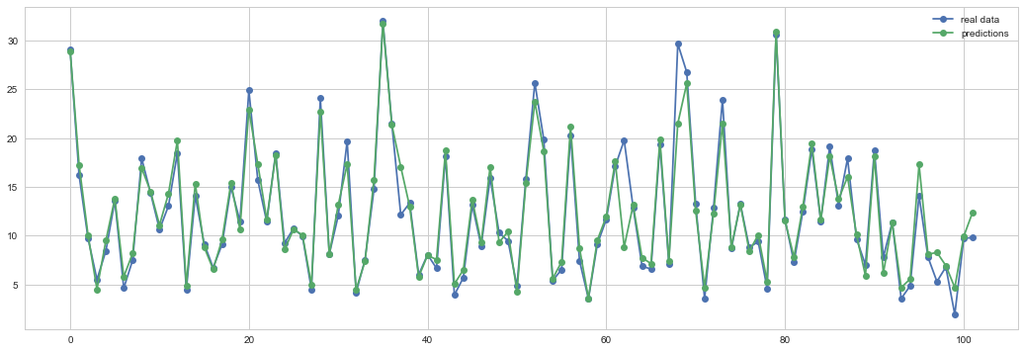

```python
# epochs=200
plt.figure(figsize=(18,6))
plt.plot(range(len(y_test4)), y_test4, '-o', label = 'real data')
plt.plot(range(len(y_test4)), y_test4_rnn_predictions, '-o', label = 'predictions')
plt.legend();
```

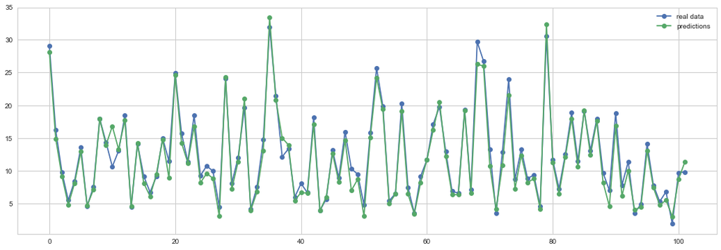

```python
# epochs=800
plt.figure(figsize=(18,6))
plt.plot(range(len(y_test4)), y_test4, '-o', label = 'real data')
plt.plot(range(len(y_test4)), y_test4_rnn_predictions, '-o', label = 'predictions')
plt.legend();
```